# Algal (non)-linear mixed model example

Version 2019-05-15 08:05:39

## Preliminaries

Inspired by a question from Diego Pujoni [on r-sig-mixed](http://article.gmane.org/gmane.comp.lang.r.lme4.devel/9363/match=), and (a few days later, presumably because there was no response) [on r-help](http://article.gmane.org/gmane.comp.lang.r.general/283733).

The parameters of the problem are that the intercept (0-day value) is known to be identical across groups and individuals.

```r
library(nlme)
library(lme4)
library(TMB)
## library(reshape2)
library(plyr)
library(ggplot2)
theme_set(theme_bw())
library(bbmle) ## for AICtab
library(splines) ## for profiles
library(broom.mixed)
```

Data:

```r
d <- data.frame(Day = rep(c(0,2,4,6,8,10),each=9),
                Group = rep(c("c","c","c","t1","t1","t1","t2","t2","t2"),6),
                Individual = factor(rep(1:9,6)),
                X = c(0.71,0.72,0.71,0.72,0.72,0.72,0.70,0.69,0.70,0.72,0.72,
                0.71,0.72,0.72,0.71,0.71,0.70,0.71,0.73,0.73,0.69,0.74,
                0.69,0.73,0.67,0.71,0.69,0.71,0.71,0.72,0.70,0.71,0.70,
                0.52,0.64,0.60,0.70,0.73,0.73,0.67,0.66,0.71,0.47,0.56,
                0.54,0.65,0.73,0.73,0.67,0.71,0.58,0.44,0.52,0.58))
```

Just for the heck of it, plot the data both with `lattice` and with `ggplot2`.

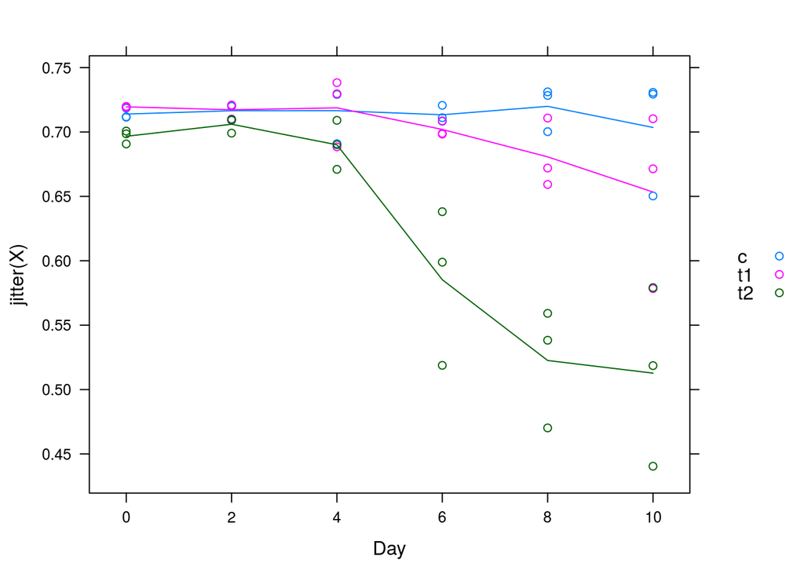

```r
library(lattice)
xyplot(jitter(X)~Day, groups=Group, data=d,type=c("a","p"),
        auto.key=list(space="right"))
```

`ggplot` version has two small advantages: 1. Add lines both by individual and group average [should be as easy with `stat_summary` as with `type="a"` in `xyplot`, but there is a bug in the latest `ggplot` version …]); 2. Adjust point size rather than jittering to visualize overlapping points.

(Both of these would of course be possible with a custom `panel.xyplot` …)

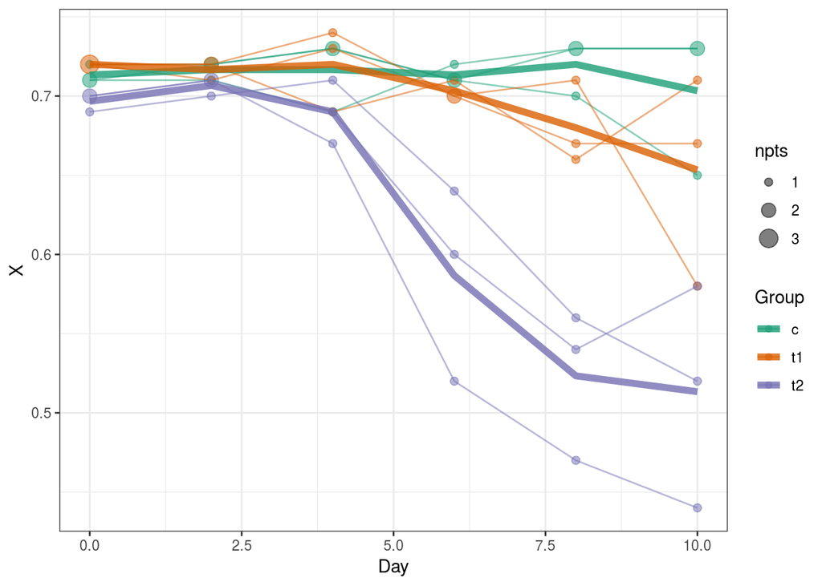

```r
## have to aggregate by hand: stat_summary bug
d2 <- ddply(d,c("Day","Group"),summarise,X=mean(X))
(g1 <- ggplot(d,aes(x=Day,y=X,colour=Group))+
    stat_sum(aes(size=factor(..n..)),alpha=0.5)+
    scale_size_discrete(range=c(2,5),name="npts")+
    geom_line(aes(group=Individual),alpha=0.5)+
    geom_line(data=d2,lwd=2,alpha=0.8)+
    scale_colour_brewer(palette="Dark2"))
```

The main conclusions from these pictures are that (1) we probably ought to be using a nonlinear rather than a linear model; (2) there might be some heteroscedasticity (larger variance at lower means, as though there is a “ceiling” to the data at $\approx X=0.7$); it does look as though there could be among-individual variation (based especially on the `t2` data, where the individual curves are approximately parallel). However, we’ll also try linear fits for illustration (even though they won’t be very good):

## Using `nlme`

Linear fits with `lme` fail:

```r
LME <- lme(X ~ 1, random = ~Day|Individual, data=d)
```

```
## Error in lme.formula(X ~ 1, random = ~Day | Individual, data = d): nlminb problem, convergence error code = 1
##   message = iteration limit reached without convergence (10)
```

If we run this with `control=lmeControl(msVerbose=TRUE)))` we get a lot of output, ending with:

```r
47:    -65.306481:  5.38940 0.705107  179.050
48:    -65.306489:  5.42212 0.705107  184.783
49:    -65.306493:  5.45375 0.705106  190.516
50:    -65.306499:  5.47352 0.705104  194.382
50:    -65.306499:  5.47352 0.705104  194.382
```

Unsurprisingly, a more complex model allowing for `Group*Day` effects fails too:

```r
LME1 <- lme(X ~ Group*Day, random = ~Day|Individual, data=d)
```

```
## Error in lme.formula(X ~ Group * Day, random = ~Day | Individual, data = d): nlminb problem, convergence error code = 1
##   message = iteration limit reached without convergence (10)
```

I tried to fit a non-linear model using `SSfpl`, a self-starting four-parameter logistic model (with parameters left-asymptote, right-asymptote, midpoint, scale parameter). This works fine for an `nls` fit, giving reasonable results:

```r
nlsfit1 <- nls(X ~ SSfpl(Day, asymp.L, asymp.R, xmid, scale),data=d)
coef(nlsfit1)
```

```
##   asymp.L   asymp.R      xmid     scale
## 0.7137817 0.6247933 6.0999046 0.9862688
```

Can use `gnls` to fit group-level differences (although for some reason I need to specify starting values, even though the help file would lead me to believe I don’t have to … perhaps I do when `params` is specified?)

My first attempt is apparently a little too ambitious for `gnls`:

```r
svec <-  list(asymp.L=0.7,
                asymp.R=c(0.6,0,0),
                xmid=c(5,0,0),
                scale=c(1,0,0))
gnlsfit1 <- gnls(
    X ~ SSfpl(Day, asymp.L, asymp.R, xmid, scale),
       data=d,
       params=list(asymp.R+scale+xmid~Group,asymp.L~1),
       start=svec)
```

```
## Error in gnls(X ~ SSfpl(Day, asymp.L, asymp.R, xmid, scale), data = d, : step halving factor reduced below minimum in NLS step
```

But I can succeed if I allow only `asymp.R` to vary among groups:

```r
svec2 <-  list(asymp.L=0.7,
                asymp.R=c(0.6,0,0),
                xmid=6,
                scale=1)
gnlsfit2 <- gnls(X ~ SSfpl(Day, asymp.L, asymp.R, xmid, scale),data=d,
       params=list(asymp.R~Group,asymp.L++scale+xmid~1),
       start=svec2)
```

Plot predicted values:

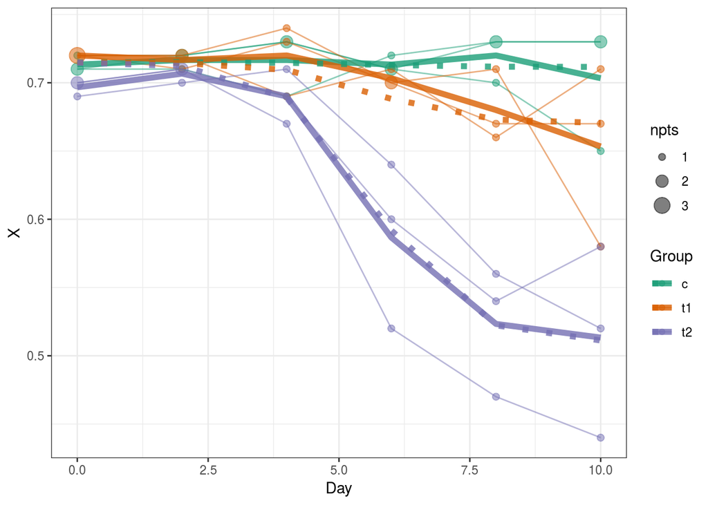

```r
predframe <- with(d,expand.grid(Day=unique(Day),Group=levels(Group)))
predframe$X <- predict(gnlsfit2,newdata=predframe)
g1 + geom_line(data=predframe,linetype=3,lwd=2,alpha=0.8)
```

These look pretty good (it would be nice to get confidence intervals too, but that’s a little bit too much of a pain for right now – need to use either delta method or bootstrapping).

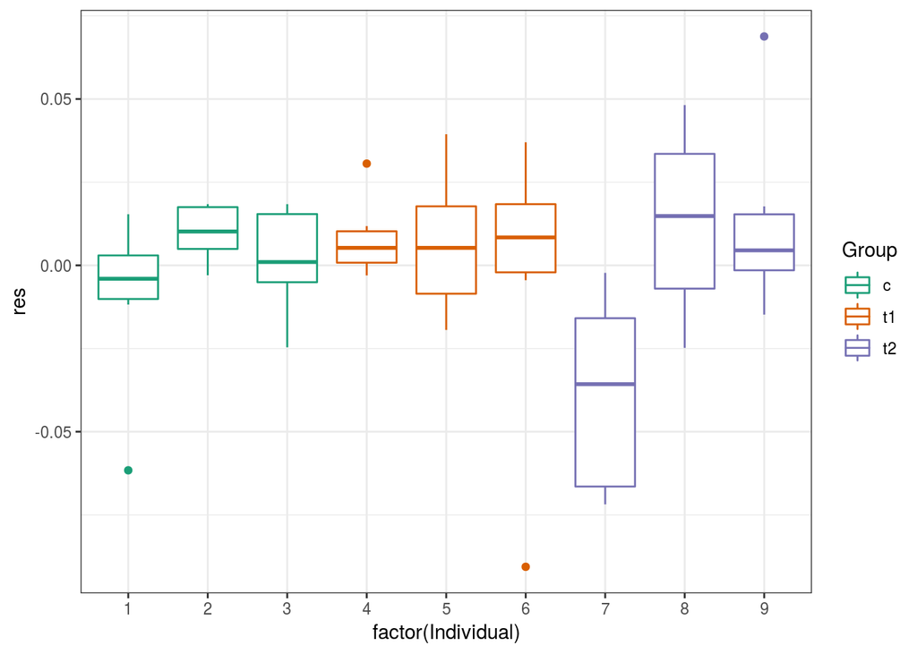

```r
dp <- data.frame(d,res=resid(gnlsfit2),fitted=fitted(gnlsfit2))
(diagplot1 <- ggplot(dp,aes(x=factor(Individual),
              y=res,colour=Group))+
      geom_boxplot(outlier.colour=NULL)+
  scale_colour_brewer(palette="Dark2"))
```

```r
anova(lm(res~Individual,data=dp))
```

```
## Analysis of Variance Table
##
## Response: res
##            Df   Sum Sq    Mean Sq F value Pr(>F)
## Individual  8 0.012934 0.00161677  2.3094 0.0362 *
## Residuals  45 0.031503 0.00070007
## ---
## Signif. codes:  0 '***' 0.001 '**' 0.01 '*' 0.05 '.' 0.1 ' ' 1
```

More general diagnostic plot – residual vs. fitted, with points from the same individual connected with lines. There is some hint of decreasing variance with increasing mean.

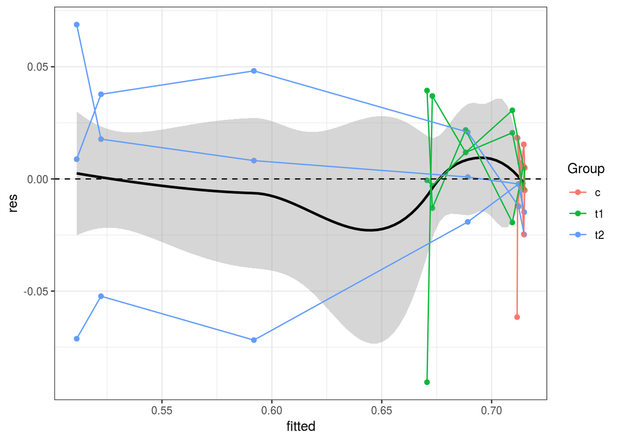

```r
(diagplot2 <- ggplot(dp,aes(x=fitted,y=res,colour=Group))+geom_point()+
  geom_smooth(aes(group=1),colour="black",method="loess")+
  geom_path(aes(group=Individual))+
  geom_hline(yintercept=0,lty=2))
```

I can’t use `nlme` with the more ambitious (three parameters varying by group) model, but I can if I only allow `asymp.R` to vary:

```r
nlmefit1 <- nlme(model  = X ~ SSfpl(Day, asymp.L, asymp.R, xmid, scale),
     fixed  = list(asymp.R ~ Group, xmid+scale+asymp.L ~1),
     random = asymp.R ~ 1 | Individual,
     start =  list(fixed=with(svec2,c(asymp.R,xmid,scale,asymp.L))),
     data=d)
```

The estimate of the variance in the right-hand asymptote is non-zero (yay):

```r
VarCorr(nlmefit1)
```

```
## Individual = pdLogChol(list(asymp.R ~ 1))
##                     Variance     StdDev
## asymp.R.(Intercept) 0.0009292421 0.03048347
## Residual            0.0004687247 0.02165005
```

Adding the random effects doesn’t change the parameters much at all:

```r
print(mm1 <- merge(data.frame(cc=coef(gnlsfit2)),
            data.frame(cc=fixef(nlmefit1)),by="row.names"),
      digits=4)
```

```
##             Row.names     cc.x     cc.y
## 1             asymp.L  0.71508  0.71514
## 2 asymp.R.(Intercept)  0.71158  0.71162
## 3     asymp.R.Groupt1 -0.04125 -0.04081
## 4     asymp.R.Groupt2 -0.20162 -0.19986
## 5               scale  0.85397  0.82750
## 6                xmid  5.65084  5.59617
```

```r
maxdiff <- max(apply(mm1[,-1],1,function(x) abs(diff(x)/mean(x))))
```

The biggest proportional difference is 3.1% (in the `scale` parameter).

```r
nlmefit2 <- update(nlmefit1,fixed  = list(asymp.R+xmid+scale+asymp.L ~1),
  start =  list(fixed=with(svec2,c(asymp.R[1],xmid,scale,asymp.L))))
```

```r
pars <- c("asymp.R.Groupt1","asymp.R.Groupt2")
ests <- fixef(nlmefit1)
V_hat <- vcov(nlmefit1)
R <- rbind(rep(0,length(ests)))
R[names(ests)  %in% pars] <- 1
W = as.numeric(t(R %*% ests) %*% solve(R %*% V_hat %*%
        t(R)) %*% (R %*% ests))
pchisq(W,df=3,lower.tail=FALSE)
```

```
## [1] 1.70405e-05
```

Better, we can compare the models via AIC or likelihood ratio test (`AICtab` from the `bbmle` package is not essential, but gives pretty output):

```r
AICtab(nlmefit1,nlmefit2,weights=TRUE)
```

```
##          dAIC df weight
## nlmefit1  0.0 8  1
## nlmefit2 14.2 6  <0.001
```

```r
anova(nlmefit1,nlmefit2)
```

```
##          Model df       AIC       BIC   logLik   Test  L.Ratio p-value
## nlmefit1     1  8 -229.2855 -213.3737 122.6428
## nlmefit2     2  6 -215.0661 -203.1321 113.5330 1 vs 2 18.21948   1e-04
```

It would be nice to do an $F$ test rather than LRT (i.e. accounting for the finite-size correction), but it’s a little bit more work (and probably not really necessary since the answer is so strong).

Check that we have the right structure:

```r
devdiff <- -2*c(logLik(nlmefit2)-logLik(nlmefit1))
pchisq(devdiff,df=2,lower.tail=FALSE)
```

```
## [1] 0.0001105833
```

```r
## F-test with very large denominator:
pf(devdiff/2,df1=2,df2=1000000,lower.tail=FALSE)
```

```
## [1] 0.0001105925
```

```
##                         Value Std.Error        DF  t.value Pr(|t|>1)
## asymp.R.(Intercept)  0.711623  0.020643 40.000000  34.4735 < 2.2e-16 ***
## asymp.R.Groupt1     -0.040814  0.029201 40.000000  -1.3977 0.1699040
## asymp.R.Groupt2     -0.199858  0.030055 40.000000  -6.6497 5.784e-08 ***
## xmid                 5.596166  0.238247 40.000000  23.4889 < 2.2e-16 ***
## scale                0.827503  0.217454 40.000000   3.8054 0.0004755 ***
## asymp.L              0.715145  0.005097 40.000000 140.3062 < 2.2e-16 ***
## ---
## Signif. codes:  0 '***' 0.001 '**' 0.01 '*' 0.05 '.' 0.1 ' ' 1
```

We don’t really know the relevant denominator df, but the summary above suggests the denominator df is 40 (based on the usual type of classical-block-design analogy for df counting, see Pinheiro and Bates 2000 or [the glmm wikidot faq](http://glmm.wikidot.com/faq)).

```r
pf(devdiff/2,df1=2,df2=40,lower.tail=FALSE)
```

```
## [1] 0.0005493295
```

## TMB

### Minimal example

First try it without random effects, grouping variables, etc. (i.e. equivalent to `nls` fit above).

```r
writeLines(con="algae1.cpp",
           "// algae example
#include <TMB.hpp>
template<class Type>
Type objective_function<Type>::operator() ()
{
  DATA_VECTOR(Day);
  DATA_VECTOR(X);
  PARAMETER(asympL);
  PARAMETER(asympR);
  PARAMETER(xmid);
  PARAMETER(scale);
  PARAMETER(logsd);
  ADREPORT(exp(2*logsd));
  // for (i=0; i<pred.size(); i++) {
  vector<Type> pred(Day.size());
  Type nll;
  pred = asympL+(asympR-asympL)/(1.0 + exp(-(Day-xmid)/scale));
  nll = -sum(dnorm(X, pred, exp(logsd), true));
  return nll;
}
")
compile("algae1.cpp")
```

```
## [1] 0
```

```r
dyn.load(dynlib("algae1"))
## set up data: adjust names, etc.
d0 <- subset(d,select=c(Day,X))
## starting values: adjust names, add values
svec3 <- svec2
names(svec3) <- gsub("\\.","",names(svec3))  ## remove dots
svec3$asympR <- 0.6 ## single value
svec3$logsd <- 1
obj <- MakeADFun(as.list(d[c("Day","X")]),
                 svec3,
                 DLL="algae1",
                 silent=TRUE)
do.call("optim",obj)
```

```
## $par
##     asympL     asympR       xmid      scale      logsd
##  0.7137819  0.6247929  6.0999104  0.9862966 -2.8070562
##
## $value
## [1] -74.95836
##
## $counts
## function gradient
##      111       31
##
## $convergence
## [1] 0
##
## $message
## NULL
```

```r
class(obj) <- "TMB"
```

Works fine:

```
##    type   term   estimate  std.error
## 1 fixed asympL  0.7137819 0.01490593
## 2 fixed asympR  0.6247929 0.02850440
## 3 fixed   xmid  6.0999104 1.31307112
## 4 fixed  scale  0.9862966 1.18603714
## 5 fixed  logsd -2.8070562 0.09622503
```

### Fixed effects model

```r
writeLines(con="algae2.cpp",
           "// algae example
#include <TMB.hpp>
template<class Type>
Type objective_function<Type>::operator() ()
{
  DATA_VECTOR(Day);
  DATA_VECTOR(X);
  DATA_MATRIX(R_X);
  PARAMETER(asympL);
  PARAMETER_VECTOR(asympR);
  PARAMETER(xmid);
  PARAMETER(scale);
  PARAMETER(logsd);
  ADREPORT(exp(2*logsd));
  vector<Type> pred(Day.size());
  vector<Type> R_val(Day.size());
  Type nll;
  R_val = R_X*asympR;
  pred = asympL+(R_val-asympL)/(1.0 + exp(-(Day-xmid)/scale));
  nll = -sum(dnorm(X, pred, exp(logsd), true));
  return nll;
}
")
compile("algae2.cpp")
```

```
## [1] 0
```

```r
dyn.load(dynlib("algae2"))
R_X <- model.matrix(~Group,data=d)
d1 <- c(d0,list(R_X=R_X))
names(svec2) <- gsub("\\.","",names(svec2))  ## remove dots
svec2$logsd <- 1
obj <- MakeADFun(d1,
                 svec2,
                 DLL="algae2",
                 silent=TRUE)
do.call("optim",obj)
```

```
## $par
##      asympL      asympR      asympR      asympR        xmid       scale
##  0.71507467  0.71158284 -0.04125626 -0.20142533  5.64671885  0.84933327
##       logsd
## -3.55133139
##
## $value
## [1] -115.1492
##
## $counts
## function gradient
##      101       26
##
## $convergence
## [1] 0
##
## $message
## NULL
```

```r
class(obj) <- "TMB"
```

```r
tidy(obj)
```

```
##    type     term    estimate   std.error
## 1 fixed   asympL  0.71507467 0.006419657
## 2 fixed   asympR  0.71158284 0.011110246
## 3 fixed asympR.1 -0.04125626 0.015829607
## 4 fixed asympR.2 -0.20142533 0.018710110
## 5 fixed     xmid  5.64671885 0.307816982
## 6 fixed    scale  0.84933327 0.320536819
## 7 fixed    logsd -3.55133139 0.096225000
```

Works, with identical parameters (except for order/names), of course.

### Random effects

Now adding the random effects.

```r
writeLines(con="algae3.cpp",
           "// algae example
#include <TMB.hpp>
template<class Type>
Type objective_function<Type>::operator() ()
{
  DATA_VECTOR(Day);
  DATA_VECTOR(X);
  DATA_MATRIX(R_X);
  DATA_SPARSE_MATRIX(R_Z);
  PARAMETER(asympL);
  PARAMETER_VECTOR(asympR);
  PARAMETER_VECTOR(R_u);
  PARAMETER(xmid);
  PARAMETER(scale);
  PARAMETER(logsd);
  PARAMETER(logsd_u);
  ADREPORT(exp(2*logsd));
  ADREPORT(exp(2*logsd_u));
  vector<Type> pred(Day.size());
  vector<Type> R_val(Day.size());
  Type nll = 0.0;
  R_val = R_X*asympR+exp(logsd_u)*(R_Z*R_u);
  pred = asympL+(R_val-asympL)/(1.0 + exp(-(Day-xmid)/scale));
  nll -= sum(dnorm(X, pred, exp(logsd), true));
  nll -= sum(dnorm(R_u, 0.0, 1.0, true));
  return nll;
}
")
compile("algae3.cpp")
```

```
## [1] 0
```

```r
dyn.load(dynlib("algae3"))
R_Z <- Matrix::sparse.model.matrix(~Individual-1,data=d)
d2 <- c(d1,list(R_Z=R_Z))
svec2B <- c(svec2, list(R_u=rep(0,9),logsd_u=0))
obj <- MakeADFun(d2,
                 svec2B,
                 DLL="algae3",
                 random="R_u",
                 silent=TRUE)
oo1 <- do.call("optim",obj)
class(obj) <- "TMB"
tidy(obj)
```

```
##    type     term    estimate   std.error
## 1 fixed   asympL  0.71533352 0.004829139
## 2 fixed   asympR  0.71151018 0.019708459
## 3 fixed asympR.1 -0.04139025 0.027915468
## 4 fixed asympR.2 -0.20212746 0.029082830
## 5 fixed     xmid  5.64839969 0.238090638
## 6 fixed    scale  0.88028407 0.248094443
## 7 fixed    logsd -3.83376579 0.105411055
## 8 fixed  logsd_u -3.47797680 0.291987939
```

```r
obj2 <- MakeADFun(d2,
                  svec2B,
                  map=list(asympR=factor(c(1,NA,NA))),
                  DLL="algae3",
                  random="R_u",
                 silent=TRUE)
oo2 <- do.call("optim",obj2)
class(obj2) <- "TMB"
tidy(obj2)
```

```
##    type    term   estimate   std.error
## 1 fixed  asympL  0.7153752 0.004834358
## 2 fixed  asympR  0.6302011 0.031525150
## 3 fixed    xmid  5.6537187 0.242067828
## 4 fixed   scale  0.8882303 0.252341802
## 5 fixed   logsd -3.8337702 0.105410048
## 6 fixed logsd_u -2.3792803 0.245245699
```